# Assignment 3: Supervised learning competition

### Random Forest model

1. Concept Random Forest is a decision tree based model which combines multiple decision trees to improve prediction accuracy and stability. It will first create multiple training subsets (bootstrap samples), then for each sample, one decision tree is created. At split node, at least two features will be considered. It will stop when trees reach to max depth or satisfy certain condition.
2. Implementation Here we use ‘caret’ which is a R package that provides algorithms include Random Forest, data preprocessing, training, evaluation, also cross-validation and hyperparameter tuning tools to build our Random Forest model.

In our implementation: - Set tunelength = 6 to try different mtry values - Set number of tree as 500 - 10 fold cross-validation

3. Model Performance

Three models is generated for Random Forest regression. The first one is trained on original data, the best result is mtry=16(The model considers 16 features) with RMSE=0.8529151 and Rsquared=0.2569956. The second one is implemented on encoded data with the same parameter, the best result is mtry=62 with RMSE=0.8874719 and Rsquared=0.1952404. For the last model, we implement model with feature selection on original data which give the best result of mtry=2, RMSE=0.8752171 and Rsquared= 0.2151779.

4. Advantages of Random Forest

First, Random Forest can deal with redundant data automatically and does not need to do correlation to select feature. Secondly, it is able to discover interactions between features. Therefore, there is not preprocessing of feature engineering in Random Forest part. Finally, it is able to reduce overfitting by ensembling trees.

5. Questions with Random Forest
- Are parameters tunelength = 6, ntree =500 enough?  
  *tunelength* in caret automatically defines numbers of *mrty* are tested when we did not specify *tuneGrid*. Random Forest is not sensitive with small changes of mtry, therefore, trying around six representative values across possible range is sufficient to find the optimal. *ntree* is the number of tree we want Random Forest to generate, 500 is a common and stable choice for sample size of our data.
- Why do model perform worse after encoding? feature selection simplify the model, does it justify the accuracy trade off?  
  The structure of the data is change after encoded. For instance, sex.M - (1,0) and sex.F - (0,1), one column is turned into two, which makes each variables less information, and it is hard for Random Forest to find a complete signal.
- mtry is higher than 30, why?  
  When the tree is split, more features are considered. For instance, sex would be split into sex.M and sex.F.
- What strategy can be used to improve?  
  Hyperparameter tuning may be used to improve by setting *tuneGrid*, increase numbers of tree or mtry. Also setting up tree depth with *maxnodes* might prevent overfitting.
1. Basic RF model

```r
# Set seed for Random Forest Model
set.seed(2025)

#tunelength is number of mtry. mtry is number of features when a tree is created.

rf_model6 <- train(
  score ~ .,
  data = train_data,
  method = "rf",
  trControl = train_control, #method is train_control
  tuneLength = 6,
  ntree=500
)
```

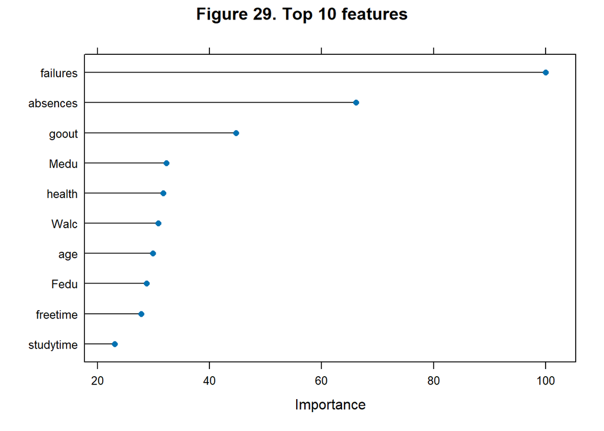

```r
# Check variables importance and plot top 10 features
importance5 <- varImp(rf_model6)
plot(importance5,top = 10,main="Figure 29. Top 10 features")
```

2. Model with encoded data

```r
rf_model_encode <- train(
  score ~ .,
  data = train_data_encode,
  method = "rf",
  trControl = train_control,
  tuneLength = 6,
  ntree=500
)
```

3. Modeling with Feature selection
- top 10 It is better than just top 10 because original top 10 might be the features that are not relevant.

```r
# Get all features with importance
imp_data <- varImp(rf_model6)$importance
imp_data$Variable <- rownames(imp_data)
imp_data <- imp_data[order(-imp_data$Overall), ]

fea_select <- function(imp_data, top_n = 10) {
  # important feature for education
  domain_val <- c("failures", "studytime", "absences", "Medu", "Fedu", "higher")

  # top 10 feature
  top_important <- head(imp_data$Variable, top_n)

  # combine and remove duplicate
  final_val <- unique(c(top_important, domain_val))

  # can only get 12 variables
  final_val <- final_val[1:min(10, length(final_val))]

  return(final_val)
}

final_selection <- fea_select(imp_data, top_n = 10)
```

```r
top10 <- c("failures","absences","goout","Medu","health","Walc","age","Fedu","freetime","studytime")

formula_top10 <- as.formula(paste("score ~", paste(top10, collapse = "+")))
```

```r
#train top10's model
rf_top10 <- train(
  formula_top10,
  data = train_data,
  method = "rf",
  trControl = train_control,
  tuneLength = 6,
  ntree=500
)
```

4. Compare between random forest models

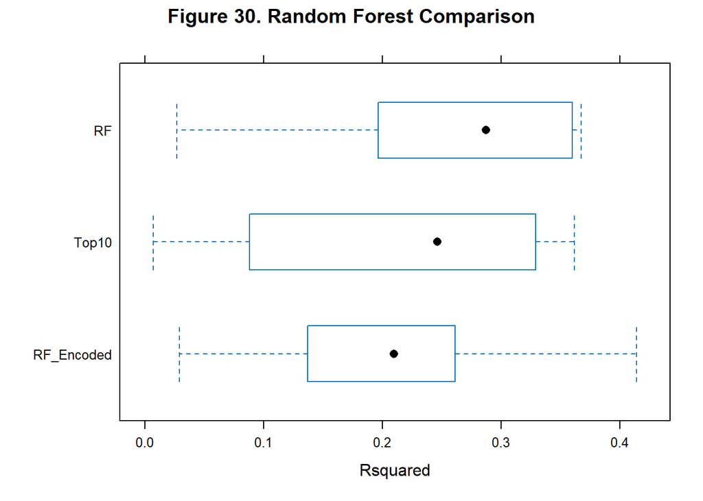

```r
results_compare_rf <- resamples(list(
  RF = rf_model6,
  RF_Encoded= rf_model_encode,
  Top10 = rf_top10
))

bwplot(results_compare_rf, metric = "Rsquared",main = "Figure 30. Random Forest Comparison")
```